# Notebook

### Web Information Retrieval and Data Mining - Assignment 3

```
Student: Teixeira Militao, Daniel (1486314)
```

#### Answer 1.1, Baseline (4p)

[output not shown]

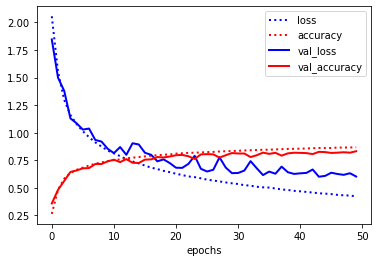

```
Model: "sequential_34"
_________________________________________________________________
Layer (type)                 Output Shape              Param #
=================================================================
reshape_25 (Reshape)         (None, 3072)              0
_________________________________________________________________
dense_113 (Dense)            (None, 256)               786688
_________________________________________________________________
dense_114 (Dense)            (None, 128)               32896
_________________________________________________________________
dense_115 (Dense)            (None, 64)                8256
_________________________________________________________________
dense_116 (Dense)            (None, 10)                650
=================================================================
Total params: 828,490
Trainable params: 828,490
Non-trainable params: 0
_________________________________________________________________
None
def build_model_1_1():
    model = models.Sequential()
    model.add(layers.Reshape((3072,), input_shape=(32,32,3)))
    model.add(layers.Dense(256, activation='relu'))
    model.add(layers.Dense(128, activation='relu'))
    model.add(layers.Dense(64, activation='relu'))
    model.add(layers.Dense(10, activation='softmax'))
    model.compile(optimizer=optimizers.SGD(),
                  loss='categorical_crossentropy',
                  metrics=['accuracy'])
    return model
```

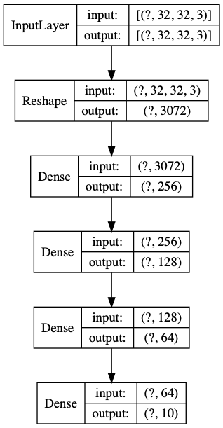

#### Answer 1.2, Preprocess (2p)

- Convert images to greyscale, other preprocessing optional.
  - Input shape should be (32,32,1)
- Explain design decisions. Is it better? Why (not)?
  - Color information is likely not so useful for classification. Greyscale makes the network smaller, less parameters to learn, less likely to overfit.

[output not shown]

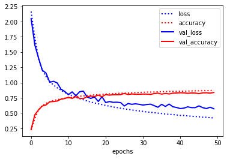

```
Model: "sequential_35"
_________________________________________________________________
Layer (type)                 Output Shape              Param #
=================================================================
reshape_26 (Reshape)         (None, 1024)              0
_________________________________________________________________
dense_117 (Dense)            (None, 256)               262400
_________________________________________________________________
dense_118 (Dense)            (None, 128)               32896
_________________________________________________________________
dense_119 (Dense)            (None, 64)                8256
_________________________________________________________________
dense_120 (Dense)            (None, 10)                650
=================================================================
Total params: 304,202
Trainable params: 304,202
Non-trainable params: 0
_________________________________________________________________
None
def build_model_1_2():
    model = models.Sequential()
    model.add(layers.Reshape((1024,), input_shape=(32,32,1)))
    model.add(layers.Dense(256, activation='relu'))
    model.add(layers.Dense(128, activation='relu'))
    model.add(layers.Dense(64, activation='relu'))
    model.add(layers.Dense(10, activation='softmax'))
    model.compile(optimizer=optimizers.SGD(),
                  loss='categorical_crossentropy',
                  metrics=['accuracy'])
    return model
```

#### Answer 1.3, Tune (4p)

- Regularize the model. What works best?
  - Should consider batch normalization, dropout, l1/l2 regularization (or Nesterov)
- Tune other hyperparameters (e.g. learning rate, batch size,...) as you see fit.
  - At least consider tuning learning rate, ideally also momentum, decay, other optimizers
- Explain your findings and final design decisions. Discuss the results.
  - Should be better, at least it shouldn't overfit

[output not shown]

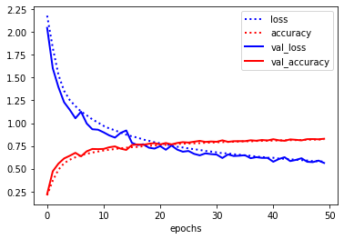

```
def build_model_1_3():
    model = models.Sequential()
    model.add(layers.Reshape((1024,), input_shape=(32,32,1)))
    model.add(layers.Dense(256, activation='relu'))
    model.add(layers.Dropout(0.05))
    model.add(layers.Dense(128, activation='relu'))
    model.add(layers.Dropout(0.1))
    model.add(layers.Dense(64, activation='relu'))
    model.add(layers.Dropout(0.2))
    model.add(layers.Dense(10, activation='softmax'))
    model.compile(optimizer=optimizers.SGD(),
                  loss='categorical_crossentropy',
                  metrics=['accuracy'])
    return model
```

#### Answer 2.1, ConvNet (7p)

[output not shown]

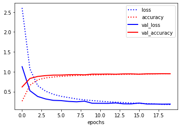

```
Model: "sequential_54"
_________________________________________________________________
Layer (type)                 Output Shape              Param #
=================================================================
conv2d_16 (Conv2D)           (None, 32, 32, 32)        320
_________________________________________________________________
batch_normalization_26 (Batc (None, 32, 32, 32)        128
_________________________________________________________________
conv2d_17 (Conv2D)           (None, 32, 32, 32)        9248
_________________________________________________________________
batch_normalization_27 (Batc (None, 32, 32, 32)        128
_________________________________________________________________
max_pooling2d_8 (MaxPooling2 (None, 16, 16, 32)        0
_________________________________________________________________
dropout_50 (Dropout)         (None, 16, 16, 32)        0
_________________________________________________________________
conv2d_18 (Conv2D)           (None, 16, 16, 64)        18496
_________________________________________________________________
batch_normalization_28 (Batc (None, 16, 16, 64)        256
_________________________________________________________________
conv2d_19 (Conv2D)           (None, 16, 16, 64)        36928
_________________________________________________________________
batch_normalization_29 (Batc (None, 16, 16, 64)        256
_________________________________________________________________
max_pooling2d_9 (MaxPooling2 (None, 8, 8, 64)          0
_________________________________________________________________
dropout_51 (Dropout)         (None, 8, 8, 64)          0
_________________________________________________________________
conv2d_20 (Conv2D)           (None, 8, 8, 128)         73856
_________________________________________________________________
batch_normalization_30 (Batc (None, 8, 8, 128)         512
_________________________________________________________________
conv2d_21 (Conv2D)           (None, 8, 8, 128)         147584
_________________________________________________________________
batch_normalization_31 (Batc (None, 8, 8, 128)         512
_________________________________________________________________
max_pooling2d_10 (MaxPooling (None, 4, 4, 128)         0
_________________________________________________________________
dropout_52 (Dropout)         (None, 4, 4, 128)         0
_________________________________________________________________
```

[output cut: 47 more lines]

```
    model.add(layers.Conv2D(256, (3, 3), activation='relu', padding='same'))
    model.add(layers.BatchNormalization())
    model.add(layers.Conv2D(256, (3, 3), activation='relu', padding='same'))
    model.add(layers.BatchNormalization())
    model.add(layers.MaxPooling2D((2, 2)))
    model.add(layers.Dropout(0.5))
    model.add(layers.Flatten())
    model.add(layers.Dense(256, activation='relu'))
    model.add(layers.BatchNormalization())
    model.add(layers.Dropout(0.5))
    model.add(layers.Dense(10, activation='softmax'))
    model.compile(optimizer=optimizers.RMSprop(learning_rate=1e-4),
                  loss='categorical_crossentropy',
                  metrics=['accuracy'])
    return model
```

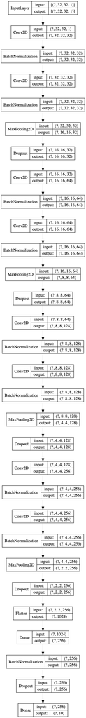

#### Answer 2.2, Data Augmentation (3p)

- Augment the preprocessed training data.
  - Use small variations (small shifts up-down, left-right) of flips becasue the images are small
  - Large shifts and rotations distort the image too much
- Explain what you did and why. Discuss the performance of the model.

[output not shown]

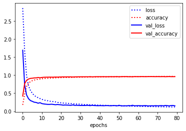

```
train_datagen = ImageDataGenerator(
    width_shift_range=0.1,
    height_shift_range=0.1,
    zoom_range=0.1)
```

#### Answer 3.1, Misclassifications (2p)

[output not shown]

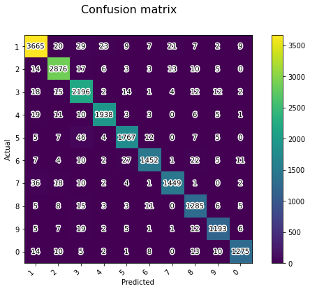

```
127
```

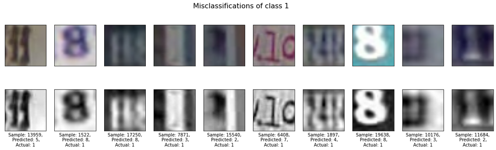

#### Answer 3.2, Activations (4p)

- Retrieve and visualize the activations for one example
- For every filter for different convolutional layers (at different depths in the network).
- Give an explanation. Is your model indeed learning something useful?
  - Should detect edges etc in first layers, higher-order object (e.g. interesting regions) in deeper layers.

[output not shown]

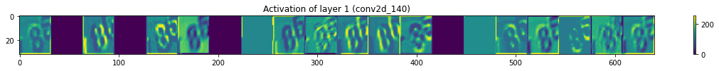

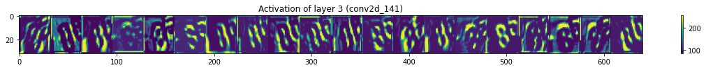

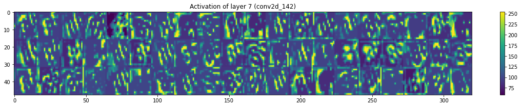

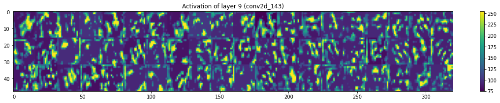

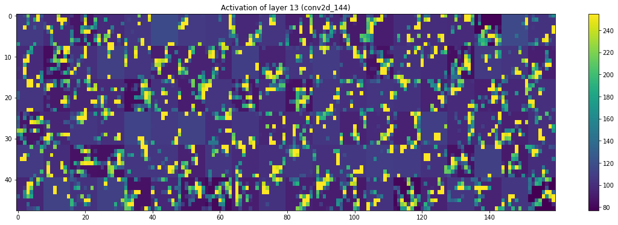

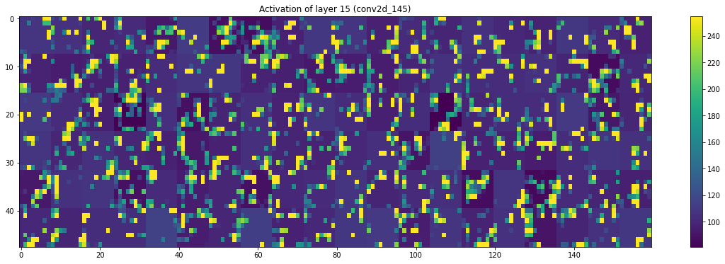

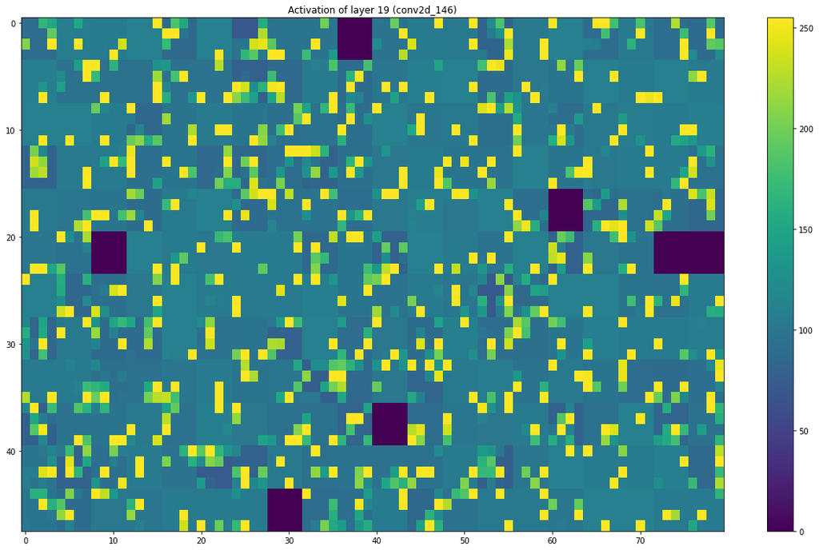

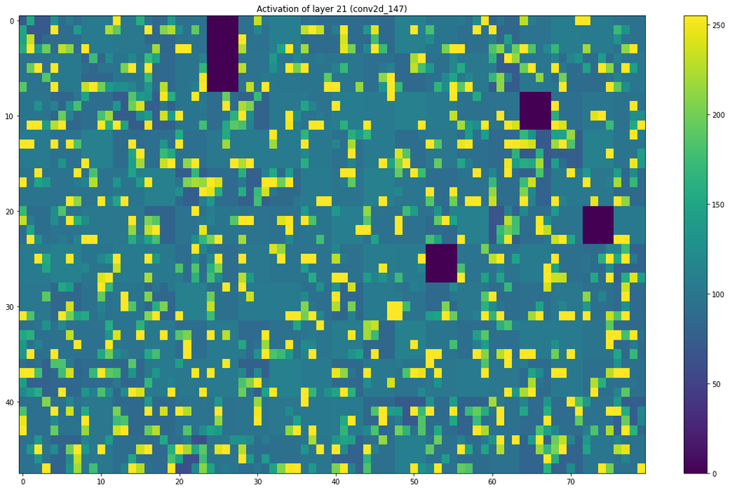

#### Answer 3.3, Class activation map (4p)

- Show a class activation map for your last convolutional layer
- Superimpose the activation map over the image, or plot side by side
  - Should make sense, detect interesting regions to classify the number

```
Predicted: 8
Actual: 8
```

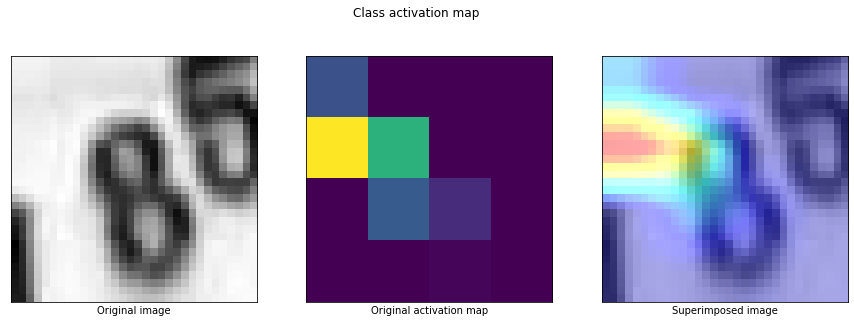

```
def plot_3_3():
    # load model
    model_2_2 = load_model_from_file(base_dir, "model_2_2")

    # get sample
    index = 0
    img = X_test_grayscale[index]
    img_tensor = np.expand_dims(img, axis=0)

    # Double check if our model actually managed to predict it correctly
    # Depending on whether or not it did, it changes how we interpret the activations
    pred = model_2_2.predict(img_tensor)
    pred_label = (np.argmax(pred)+1)%10
    actual_label = (np.argmax(y_test[index])+1)%10
    print("Predicted: %d\nActual: %d" % (pred_label, actual_label))

    with tf.GradientTape() as tape:
        last_conv_layer = model_2_2.get_layer('conv2d_147')
        iterate = tf.keras.models.Model([model_2_2.inputs], [model_2_2.output, last_conv_layer.output])
        model_out, last_conv_layer = iterate(img_tensor)
        class_out = model_out[:, np.argmax(model_out[0])]
        grads = tape.gradient(class_out, last_conv_layer)
        pooled_grads = K.mean(grads, axis=(0, 1, 2))

    heatmap = tf.reduce_mean(tf.multiply(pooled_grads, last_conv_layer), axis=-1)
    heatmap = np.maximum(heatmap, 0)
    heatmap /= np.max(heatmap)
    heatmap = heatmap.reshape((4, 4))

    INTENSITY = 0.002
    # We resize the heatmap to have the same size as the original image
    heatmap_cv2 = cv2.resize(heatmap, (img.shape[1], img.shape[0]))
    # We convert the heatmap to RGB
    heatmap_cv2 = np.uint8(255 * heatmap_cv2)
    # We apply the heatmap to the original image
    heatmap_cv2 = cv2.applyColorMap(heatmap_cv2, cv2.COLORMAP_JET)
    # We make sure it's RGB because for some GOD DAMN REASON CV2 IS BRG AND IT TOOK TOO LONG TO FIGURE THAT OUT
    heatmap_cv2 = cv2.cvtColor(heatmap_cv2, cv2.COLOR_BGR2RGB)
    superimposed_img = heatmap_cv2 * INTENSITY + img

    fig, ax = plt.subplots(1, 3, figsize=(15, 5))
    im = np.squeeze(img)
    ax[0].imshow(im, cmap='gray')
    ax[0].set_xlabel("Original image")
    ax[0].set_xticks(()), ax[0].set_yticks(())

    ax[1].matshow(heatmap)
    ax[1].set_xlabel("Original activation map")
    ax[1].set_xticks(()), ax[1].set_yticks(())

    ax[2].imshow(superimposed_img)
    ax[2].set_xlabel("Superimposed image")
    ax[2].set_xticks(()), ax[2].set_yticks(())

    fig.suptitle('Class activation map')
    plt.show();
```

#### Answer 4.1, Fast feature extraction (5p)

- Import the VGG16 model, pretrained on ImageNet
- Freeze convolutional base, adds a dense layer
- Consider unfreezing the last few convolutional layers and evaluate whether that works better
  - Check if they do. It is very likely to help.
- Discuss the observed performance
  - Should get around 80% accuracy

[output not shown]

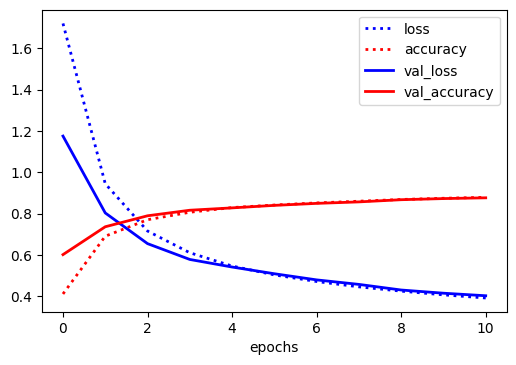

```
Model: "sequential_16"
_________________________________________________________________
Layer (type)                 Output Shape              Param #
=================================================================
vgg16 (Model)                (None, 1, 1, 512)         14714688
_________________________________________________________________
flatten_12 (Flatten)         (None, 512)               0
_________________________________________________________________
dense_40 (Dense)             (None, 256)               131328
_________________________________________________________________
dense_41 (Dense)             (None, 10)                2570
=================================================================
Total params: 14,848,586
Trainable params: 14,588,426
Non-trainable params: 260,160
_________________________________________________________________
None
def build_model_4_1():
    vgg16_conv_base = VGG16(weights='imagenet',
                            include_top=False,
                            input_shape=(32, 32, 3))
    model = models.Sequential()
    model.add(vgg16_conv_base)
    model.add(layers.Flatten())
    model.add(layers.Dense(256, activation='relu'))
    model.add(layers.Dense(10, activation='sigmoid'))
    vgg16_conv_base.trainable = True
    set_trainable = False
    for layer in vgg16_conv_base.layers:
        if layer.name.startswith('block3'):
            set_trainable = True
        if set_trainable:
            layer.trainable = True
        else:
            layer.trainable = False
    model.compile(optimizer=optimizers.RMSprop(learning_rate=1e-6),
                  loss='categorical_crossentropy',
                  metrics=['accuracy'])
    return model
```

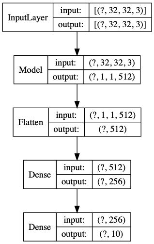

#### Answer 4.2, Embeddings (5p)

- Generate embeddings with the trained convolutional part of model_4_1 (without the dense layer)
- Embed the training and test data and store them to disk
- Build and evaluate a pipeline on the embedded data
  - Check if pipeline makes sense (e.g. use models that can handle many dimensions)
- Describe what you did and what you observed (max 800 chars).
  - Consider different models, preprocessing, tuning, etc.
  - Check performance (see original Submission.html) when in doubt. We did not run all the evaluations because it takes too long, and the output is ill-defined.

[output not shown]

```
Running time: 20.86 seconds
Last modified: May 26, 2020
scikit-learn version: 0.23.1
```